# CSP571 Project Data Prep and Transformations

Khushin Patel

### Value Checking -Khush

```r
# lets see the first 10 of the data we're working with
main_data = read.csv("./Data Files/data_sp.csv")
head(main_data, 10)
```

|  | X | Date | Close.Last | Volume | Open | High | Low | change | change_cat | moon | slash | plus | star | two | lunar | solar | flare |
| --- | --- | --- | --- | --- | --- | --- | --- | --- | --- | --- | --- | --- | --- | --- | --- | --- | --- |
| 1 | 1 | 2024-03-28 | 52.22 | 193446 | 51.92 | $52.35 | $51.75 | -0.30 | 0 | 0 | 0 | 0 | 0 | 0 | 0 | 0 | 0 |
| 2 | 2 | 2024-03-27 | 51.97 | 138328 | 51.95 | $51.97 | $51.87 | -0.02 | 0 | 0 | 0 | 0 | 0 | 0 | 0 | 0 | 0 |
| 3 | 3 | 2024-03-26 | 51.96 | 108319 | 52.00 | $52.00 | $51.91 | 0.04 | 1 | 0 | 0 | 0 | 0 | 0 | 0 | 0 | 0 |
| 4 | 4 | 2024-03-25 | 51.98 | 127264 | 51.88 | $52.02 | $51.8011 | -0.10 | 0 | 1 | 1 | 0 | 0 | 0 | 1 | 0 | 0 |
| 5 | 5 | 2024-03-22 | 51.88 | 75197 | 51.94 | $51.95 | $51.75 | 0.06 | 1 | 0 | 0 | 0 | 0 | 0 | 0 | 0 | 0 |
| 6 | 6 | 2024-03-21 | 51.80 | 88651 | 52.06 | $52.10 | $51.80 | 0.26 | 1 | 0 | 0 | 0 | 0 | 0 | 0 | 0 | 0 |
| 7 | 7 | 2024-03-20 | 51.95 | 137254 | 51.76 | $52.06 | $51.72 | -0.19 | 0 | 0 | 0 | 0 | 0 | 0 | 0 | 0 | 0 |
| 8 | 8 | 2024-03-19 | 51.74 | 406715 | 51.73 | $51.80 | $51.70 | -0.01 | 0 | 0 | 0 | 0 | 0 | 0 | 0 | 0 | 0 |
| 9 | 9 | 2024-03-18 | 51.72 | 47008 | 51.69 | $51.75 | $51.69 | -0.03 | 0 | 0 | 0 | 0 | 0 | 0 | 0 | 0 | 0 |
| 10 | 10 | 2024-03-15 | 51.70 | 129652 | 51.59 | $51.75 | $51.59 | -0.11 | 0 | 0 | 0 | 0 | 0 | 0 | 0 | 0 | 0 |

### Select the features and the predictor variable out of the data. We will also take the change column as net_change. Let’s also add a categorical vaiable called cat_change that tells us if the change is positive(1) or negative(0)

```r
predictor_columns <- c("moon", "slash", "plus", "star", "two", "lunar", "solar", "flare")
processed_data = main_data[, predictor_columns]
processed_data$net_change = main_data$change
processed_data$cat_change = main_data$change_cat
head(processed_data, 10)
```

|  | moon | slash | plus | star | two | lunar | solar | flare | net_change | cat_change |
| --- | --- | --- | --- | --- | --- | --- | --- | --- | --- | --- |
| 1 | 0 | 0 | 0 | 0 | 0 | 0 | 0 | 0 | -0.30 | 0 |
| 2 | 0 | 0 | 0 | 0 | 0 | 0 | 0 | 0 | -0.02 | 0 |
| 3 | 0 | 0 | 0 | 0 | 0 | 0 | 0 | 0 | 0.04 | 1 |
| 4 | 1 | 1 | 0 | 0 | 0 | 1 | 0 | 0 | -0.10 | 0 |
| 5 | 0 | 0 | 0 | 0 | 0 | 0 | 0 | 0 | 0.06 | 1 |
| 6 | 0 | 0 | 0 | 0 | 0 | 0 | 0 | 0 | 0.26 | 1 |
| 7 | 0 | 0 | 0 | 0 | 0 | 0 | 0 | 0 | -0.19 | 0 |
| 8 | 0 | 0 | 0 | 0 | 0 | 0 | 0 | 0 | -0.01 | 0 |
| 9 | 0 | 0 | 0 | 0 | 0 | 0 | 0 | 0 | -0.03 | 0 |
| 10 | 0 | 0 | 0 | 0 | 0 | 0 | 0 | 0 | -0.11 | 0 |

### Let’s now see the distribution of the positive(1) class and the negative class in the predictors

```r
frequency_tables <- lapply(processed_data[,predictor_columns], table)
frequency_tables
```

```
$moon

   0    1
2430   86

$slash

   0    1
2509    7

$plus

   0    1
2513    3

$star

   0    1
2513    3

$two

   0    1
2508    8

$lunar

   0    1
2498   18

$solar

   0    1
2502   14

$flare

   0    1
2515    1
```

### All of the predictors are heavily imbalanced we first have to balance them

#### To address this imbalance I will take the number of rows where any of the predictor columns have a minority value of 1 and sample the same number of rows from the majority class(0)

```r
imbalanced_predictors = c("moon", "slash", "plus", "star", "two", "lunar", "solar", "flare")

# GPT generated code
majority_class <- subset(processed_data, rowSums(processed_data[imbalanced_predictors]) == 0)
minority_class <- subset(processed_data, rowSums(processed_data[imbalanced_predictors]) > 0)

undersampled_majority <- majority_class[sample(nrow(majority_class), nrow(minority_class), replace = FALSE), ]

# Combine undersampled majority class and minority class
balanced_data <- rbind(undersampled_majority, minority_class)
head(balanced_data, 10)
```

|  | moon | slash | plus | star | two | lunar | solar | flare | net_change | cat_change |
| --- | --- | --- | --- | --- | --- | --- | --- | --- | --- | --- |
| 260 | 0 | 0 | 0 | 0 | 0 | 0 | 0 | 0 | 0.08 | 1 |
| 1468 | 0 | 0 | 0 | 0 | 0 | 0 | 0 | 0 | -0.15 | 0 |
| 1556 | 0 | 0 | 0 | 0 | 0 | 0 | 0 | 0 | 0.65 | 1 |
| 994 | 0 | 0 | 0 | 0 | 0 | 0 | 0 | 0 | 0.23 | 1 |
| 367 | 0 | 0 | 0 | 0 | 0 | 0 | 0 | 0 | 0.73 | 1 |
| 194 | 0 | 0 | 0 | 0 | 0 | 0 | 0 | 0 | 0.28 | 1 |
| 1038 | 0 | 0 | 0 | 0 | 0 | 0 | 0 | 0 | 0.34 | 1 |
| 594 | 0 | 0 | 0 | 0 | 0 | 0 | 0 | 0 | 0.32 | 1 |
| 379 | 0 | 0 | 0 | 0 | 0 | 0 | 0 | 0 | 0.53 | 1 |
| 1349 | 0 | 0 | 0 | 0 | 0 | 0 | 0 | 0 | -0.33 | 0 |

```r
# lets see how the data is distributed now in our balanced dataset and shuffle it
balanced_data <- balanced_data[sample(nrow(balanced_data)), ]
frequency_tables <- lapply(balanced_data[,imbalanced_predictors], table)
frequency_tables
```

```
$moon

  0   1
116  86

$slash

  0   1
195   7

$plus

  0   1
199   3

$star

  0   1
199   3

$two

  0   1
194   8

$lunar

  0   1
184  18

$solar

  0   1
188  14

$flare

  0   1
201   1
```

#### It is still quite imbalanced but it is better than before but if we undersample the majority class even more, we might lose too much information. We’ve already lost a lot of it by undersampling the majority class.

#### Lets now see the correlations here between the undersampled predictors and the target

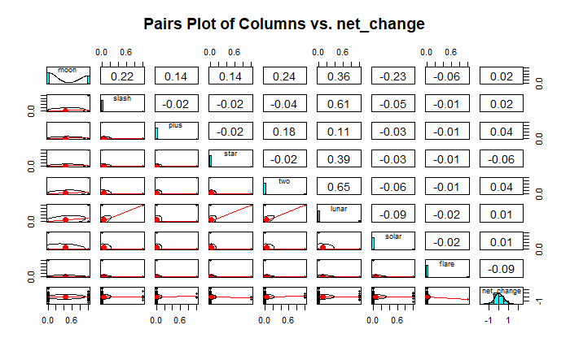

```r
library(psych)
columns_for_pairs <- c(imbalanced_predictors, "net_change")
# Create pairs plot
pairs.panels(balanced_data[columns_for_pairs], main = "Pairs Plot of Columns vs. net_change")
```

#### It seems like flare is the only one that has even a small correlation with net_change all the other ones are very faintly correlated. Maybe we will see a correlation if we combine them all into just one variable that signifies that there was some solar event occuring on that day. Lets first consider how it is distributed if we do all of the initial rows

```r
processed_data$has_event = ifelse(rowSums(processed_data[, imbalanced_predictors]) > 0, 1, 0)
head(processed_data, 10)
```

|  | moon | slash | plus | star | two | lunar | solar | flare | net_change | cat_change | has_event |
| --- | --- | --- | --- | --- | --- | --- | --- | --- | --- | --- | --- |
| 1 | 0 | 0 | 0 | 0 | 0 | 0 | 0 | 0 | -0.30 | 0 | 0 |
| 2 | 0 | 0 | 0 | 0 | 0 | 0 | 0 | 0 | -0.02 | 0 | 0 |
| 3 | 0 | 0 | 0 | 0 | 0 | 0 | 0 | 0 | 0.04 | 1 | 0 |
| 4 | 1 | 1 | 0 | 0 | 0 | 1 | 0 | 0 | -0.10 | 0 | 1 |
| 5 | 0 | 0 | 0 | 0 | 0 | 0 | 0 | 0 | 0.06 | 1 | 0 |
| 6 | 0 | 0 | 0 | 0 | 0 | 0 | 0 | 0 | 0.26 | 1 | 0 |
| 7 | 0 | 0 | 0 | 0 | 0 | 0 | 0 | 0 | -0.19 | 0 | 0 |
| 8 | 0 | 0 | 0 | 0 | 0 | 0 | 0 | 0 | -0.01 | 0 | 0 |
| 9 | 0 | 0 | 0 | 0 | 0 | 0 | 0 | 0 | -0.03 | 0 | 0 |
| 10 | 0 | 0 | 0 | 0 | 0 | 0 | 0 | 0 | -0.11 | 0 | 0 |

```r
NA
```

#### lets see if this shows any correlations

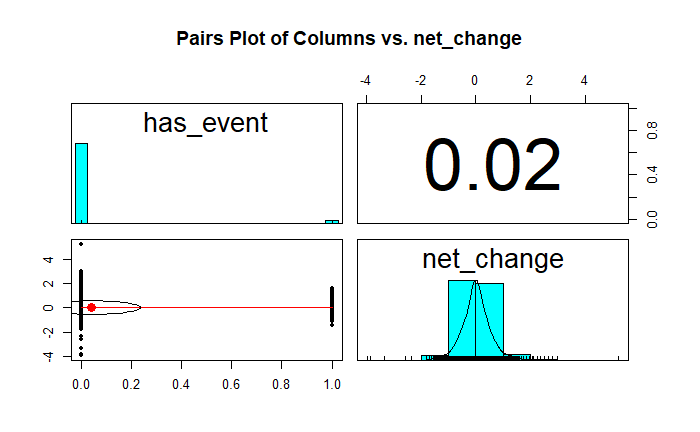

```r
columns_for_pairs <- c("has_event", "net_change")
# Create pairs plot
pairs.panels(processed_data[columns_for_pairs], main = "Pairs Plot of Columns vs. net_change")
```

#### still doesn’t seem good lets try the same thing with the balanced dataset

```r
balanced_data$has_event = ifelse(rowSums(balanced_data[, imbalanced_predictors]) > 0, 1, 0)
head(balanced_data, 10)
```

|  | moon | slash | plus | star | two | lunar | solar | flare | net_change | cat_change | has_event |
| --- | --- | --- | --- | --- | --- | --- | --- | --- | --- | --- | --- |
| 1753 | 1 | 0 | 0 | 0 | 0 | 0 | 0 | 0 | 0.00 | 1 | 1 |
| 1271 | 0 | 0 | 0 | 0 | 0 | 0 | 0 | 0 | 0.27 | 1 | 0 |
| 1177 | 0 | 0 | 0 | 0 | 0 | 0 | 0 | 0 | -0.58 | 0 | 0 |
| 4 | 1 | 1 | 0 | 0 | 0 | 1 | 0 | 0 | -0.10 | 0 | 1 |
| 167 | 1 | 0 | 0 | 0 | 0 | 0 | 0 | 0 | 0.00 | 1 | 1 |
| 1539 | 0 | 0 | 0 | 0 | 0 | 0 | 1 | 0 | 1.10 | 1 | 1 |
| 494 | 0 | 0 | 0 | 0 | 0 | 0 | 0 | 0 | 1.38 | 1 | 0 |
| 1733 | 1 | 0 | 0 | 0 | 0 | 0 | 0 | 0 | 0.00 | 1 | 1 |
| 358 | 0 | 0 | 0 | 0 | 0 | 0 | 1 | 0 | -1.16 | 0 | 1 |
| 851 | 0 | 0 | 0 | 0 | 0 | 0 | 0 | 0 | -0.86 | 0 | 0 |

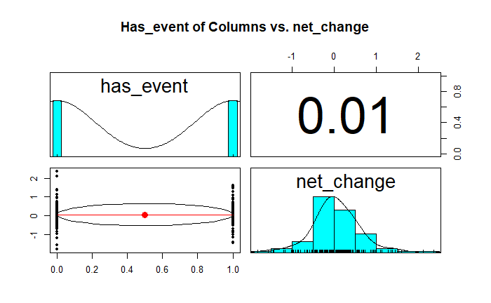

```r
pairs.panels(balanced_data[columns_for_pairs], main = "Has_event of Columns vs. net_change")
```

#### Similarly We don’t see any significant correlation here

### Lets try to see if we can see a correlation if we use categorical change as the target in this using the imbalanced dataset

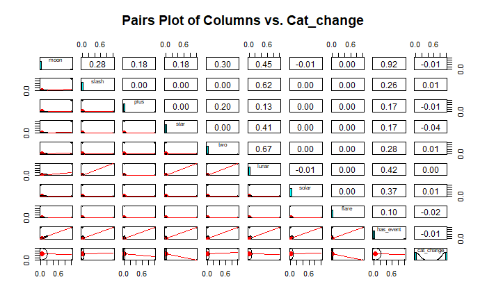

```r
columns_for_pairs <- c(imbalanced_predictors, "has_event", "cat_change")
# Create pairs plot
pairs.panels(processed_data[columns_for_pairs], main = "Pairs Plot of Columns vs. Cat_change")
```

#### none of them seem to show any correlation here

#### now lets see if similary we can get something out of the balanced dataset

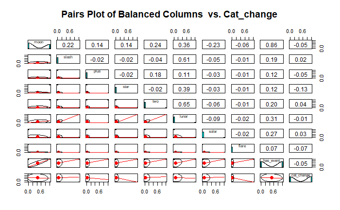

```r
predictor_columns <- c("moon", "slash",  "plus", "star", "two", "lunar", "solar", "flare")

columns_for_pairs <- c(imbalanced_predictors, "has_event", "cat_change")
# Create pairs plot
pairs.panels(balanced_data[columns_for_pairs], main = "Pairs Plot of Balanced Columns  vs. Cat_change")
```

### Models: Decision Tree

#### We will build a decision tree model that will use values of the predictor_columns to predict cat_change

##### Lets first split both the balanced and imbalanced datasets into their training(80%) and testing(20%) indices. We will also only use the predictor columns for predictors in the tree

```r
train_indices <- sample(1:nrow(balanced_data), size = round(0.8 * nrow(balanced_data)))
train_balanced_data <- balanced_data[train_indices, c(predictor_columns, "cat_change")]
test_balanced_data <- balanced_data[-train_indices, c(predictor_columns, "cat_change")]

train_indices <- sample(1:nrow(processed_data), size = round(.8 * nrow(processed_data)))
train_processed_data <- processed_data[train_indices, c(predictor_columns, "cat_change")]
test_processed_data <- processed_data[-train_indices, c(predictor_columns, "cat_change")]
```

##### Now lets build a decision tree on both datasets

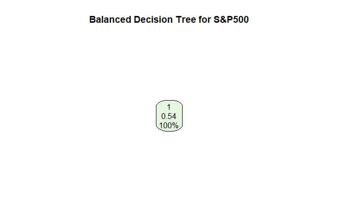

```r
library(rpart)
library(rpart.plot)

tree_balanced <- rpart(cat_change ~ ., data = train_balanced_data, method = "class")
rpart.plot(tree_balanced, main = "Balanced Decision Tree for S&P500")
```

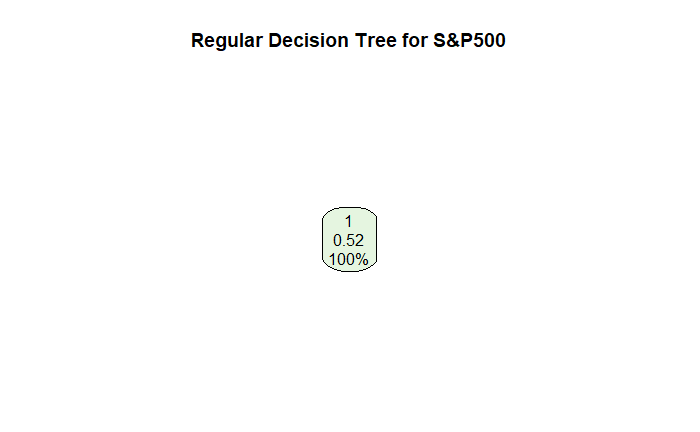

```r
tree_processed <- rpart(cat_change ~ ., data = train_processed_data, method = "class")
rpart.plot(tree_processed, main = "Regular Decision Tree for S&P500")
```

```r
predictions <- predict(tree_balanced, test_balanced_data, type = "class")

# Calculate accuracy
accuracy <- mean(predictions == test_balanced_data$cat_change)
cat("Accuracy:", accuracy, "\n")
```

```
Accuracy: 0.45
```

```r
# Calculate confusion matrix
confusion_matrix <- table(Predicted = predictions, Actual = test_balanced_data$cat_change)

# Calculate precision, recall, and F1-score
precision <- confusion_matrix[2, 2] / sum(confusion_matrix[, 2])
recall <- confusion_matrix[2, 2] / sum(confusion_matrix[2, ])
f1_score <- 2 * precision * recall / (precision + recall)

cat("Precision:", precision, "\n")
```

```
Precision: 1
```

```r
cat("Recall:", recall, "\n")
```

```
Recall: 0.45
```

```r
cat("F1-score:", f1_score, "\n")
```

```
F1-score: 0.6206897
```

```r
confusion_matrix
```

```
         Actual
Predicted  0  1
        0  0  0
        1 22 18
```

```r
library(randomForest)
library(randomForestExplainer)

rf_model <- randomForest(cat_change ~ ., data = train_balanced_data, method = "class")
importance <- importance(rf_model)
importance
```

```
      IncNodePurity
moon      0.2270593
slash     0.2008409
plus      0.1762156
star      0.5102221
two       0.1881459
lunar     0.1916002
solar     0.1557034
flare     0.1681226
```

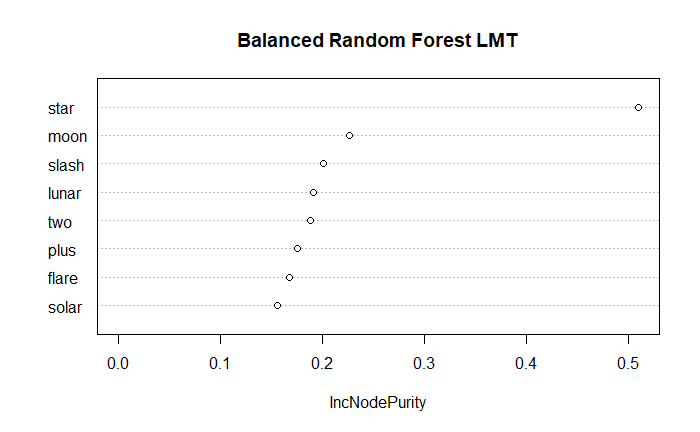

```r
# Plot feature importance
varImpPlot(rf_model, main = "Balanced Random Forest LMT")
```

```r
predictions <- round(predict(rf_model, processed_data, type = "class"))

# Calculate accuracy
accuracy <- mean(predictions == processed_data$cat_change)
cat("Accuracy:", accuracy, "\n")
```

```
Accuracy: 0.5198728
```

```r
# Calculate confusion matrix
confusion_matrix <- table(Predicted = predictions, Actual = processed_data$cat_change)

# Calculate precision, recall, and F1-score
precision <- confusion_matrix[2, 2] / sum(confusion_matrix[, 2])
recall <- confusion_matrix[2, 2] / sum(confusion_matrix[2, ])
f1_score <- 2 * precision * recall / (precision + recall)

cat("Precision:", precision, "\n")
```

```
Precision: 0.9746544
```

```r
cat("Recall:", recall, "\n")
```

```
Recall: 0.5192308
```

```r
cat("F1-score:", f1_score, "\n")
```

```
F1-score: 0.6775227
```

```r
confusion_matrix
```

```
         Actual
Predicted    0    1
        0   39   33
        1 1175 1269
```